# Reproducible Research: Peer Assessment 1

Antonio Guerreiro

29/07/2017

## Loading the data

```r
activity <- read.csv("activity.csv")
```

## What is mean total number of steps taken per day?

For this part we ignore (remove) the missing values in the dataset.

```r
noNA_activity = na.omit(activity)
```

Make a histogram of the total number of steps taken each day.

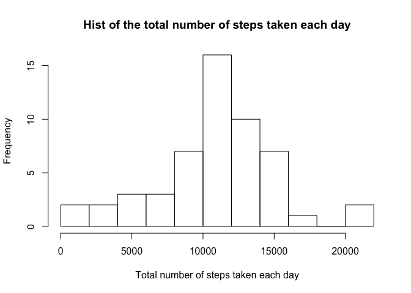

```r
hist(aggregate(noNA_activity$steps, list(noNA_activity$date), sum)$x,
    breaks = 10, main = "Hist of the total number of steps taken each day",
    xlab = "Total number of steps taken each day")
```

Calculate and report the mean and median total number of steps taken per day.

Mean total number of steps taken per day, without imputing missing values:

```r
asis_mean <- mean(aggregate(noNA_activity$steps, list(noNA_activity$date), sum)$x)
asis_mean
```

```
## [1] 10766.19
```

Median total number of steps taken per day, without imputing missing values:

```r
asis_median <- median(aggregate(noNA_activity$steps, list(noNA_activity$date), sum)$x)
asis_median
```

```
## [1] 10765
```

## What is the average daily activity pattern?

Make a time series plot of the 5-minute intervals (x-axis) and the average number of steps taken, averaged across all days (y-axis).

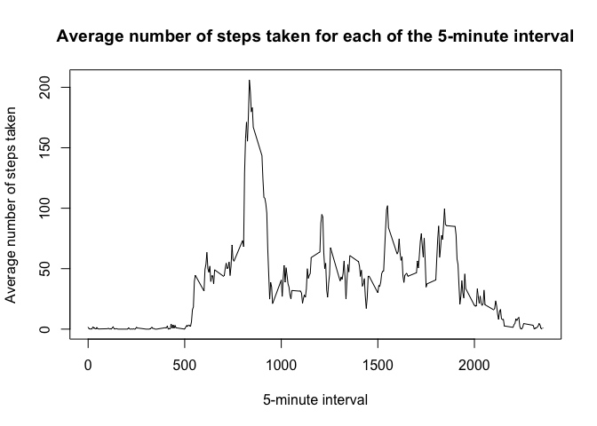

```r
interval_means <- aggregate(noNA_activity$steps, list(noNA_activity$interval), mean)
plot(interval_means$Group.1, interval_means$x, type = "l",
     main = "Average number of steps taken for each of the 5-minute interval",
     xlab = "5-minute interval", ylab = "Average number of steps taken")
```

Which 5-minute interval, on average across all the days in the dataset, contains the maximum number of steps?

Interval:

```r
interval_means[interval_means$x == max(interval_means$x),]$Group.1
```

```
## [1] 835
```

Value:

```r
interval_means[interval_means$x == max(interval_means$x),]$x
```

```
## [1] 206.1698
```

## Imputing missing values

Calculate and report the total number of missing values in the original dataset (i.e. the total number of rows with NAs).

Total number of rows with NAs:

```r
nrow(activity[is.na(activity$steps),])
```

```
## [1] 2304
```

Devise a strategy for filling in all of the missing values in the dataset.

Stategy used for filling in all of the missing values in the dataset: we use the mean value computed previously for that this interval.

Create a new dataset that is equal to the original dataset but with the missing data filled in.

```r
for (n in 1:nrow(activity)) {
  if (is.na(activity$steps[n])) {
    activity$steps[n] <- round(interval_means[interval_means$Group.1 == activity$interval[n],]$x)
  }
}
```

Make a histogram of the total number of steps taken each day.

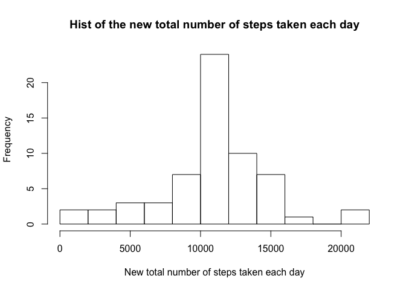

```r
hist(aggregate(activity$steps, list(activity$date), sum)$x,
     breaks = 10, main = "Hist of the new total number of steps taken each day",
     xlab = "New total number of steps taken each day")
```

Calculate and report the mean and median total number of steps taken per day.

Mean total number of steps taken per day, inputing missing values:

```r
new_mean <- mean(aggregate(activity$steps, list(activity$date), sum)$x)
new_mean
```

```
## [1] 10765.64
```

vs:

```r
asis_mean
```

```
## [1] 10766.19
```

Median total number of steps taken per day, inputing missing values:

```r
new_median <- median(aggregate(activity$steps, list(activity$date), sum)$x)
new_median
```

```
## [1] 10762
```

vs:

```r
asis_median
```

```
## [1] 10765
```

Estimates are quite similar with our without inputing missing values (as I used “round(mean())” for inputing…).

## Are there differences in activity patterns between weekdays and weekends?

Create a new factor variable in the dataset with two levels “weekday” and “weekend” indicating whether a given date is a weekday or weekend day.

French localized computer.

```r
activity$day <- weekdays(as.Date(activity$date),abbreviate = FALSE)

for (n in 1:nrow(activity)) {
  if (activity$day[n] == "Samedi" || activity$day[n] == "Dimanche") {
    activity$daytype[n] <- "weekend"
  } else {
    activity$daytype[n] <- "weekday"
  }
}
```

Make a panel plot containing a time series plot of the 5-minute interval (x-axis) and the average number of steps taken, averaged across all weekday days or weekend days (y-axis).

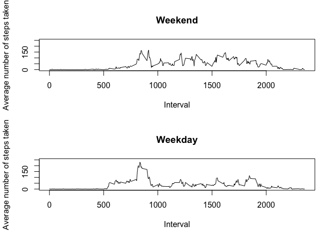

```r
weekend_activity <- activity[activity$daytype == "weekend",]
weekday_activity <- activity[activity$daytype == "weekday",]

par(mfrow=c(2,1))
plot(
  aggregate(weekend_activity$steps, list(weekend_activity$interval), mean)$Group.1,
  aggregate(weekend_activity$steps, list(weekend_activity$interval), mean)$x,
  type = "l", main ="Weekend", xlab = "Interval", ylab = "Average number of steps taken",  ylim=c(0, 250))

plot(
  aggregate(weekday_activity$steps, list(weekday_activity$interval), mean)$Group.1,
  aggregate(weekday_activity$steps, list(weekday_activity$interval), mean)$x,
  type = "l", main =  "Weekday", xlab = "Interval", ylab = "Average number of steps taken", ylim=c(0, 250))
```